# cind802 Project - Descriptive Statistics

Austin Okafor

2022-06-12

DESCRIPTIVE STATISTICS:

Missing information and unknown values were entered as -99 and -88 respectively. These need to be replaced with NA so as not to distort the analysis outcomes.

## Importing the dataset and converting -88 and -99 into NA’s since these represnt missing data in the dataset

```r
#-99 and -88 represent missing or unknown values in the dataset. We need to set them to NA when importing the data.

mna <- c(-99, -88)

dssDataset <- read.csv("developmental_services_survey_dataset_0.csv",
                       header = TRUE,
                       stringsAsFactors = F,
                       na.strings = c(mna,"NA"))

head(dssDataset)
```

```
##   UID SERVICES PR_Q3D PR_AGE1 PR_QF1A PR_QF1B PR_QF1C PR_QG1A PR_QG1B PR_QG1C
## 1   1        3      1       1       1       1      NA       1       1      NA
## 2   2        3      1       2       1       1      NA       1       1      NA
## 3   3        3      2       1       1       1      NA       1       1      NA
## 4   4        3      1       2       1       1      NA       1       1      NA
## 5   5        3      2       2       1       1      NA       1       1      NA
## 6   6        3      1       2       1       1      NA       1       1      NA
##   PR_QH1A PR_QH1B PR_QI1 PR_QJ1 PR_QK1 PR_QL1 PR_QL1A_1 PR_QL1A_2 PR_QL1A_3
## 1       1      NA      1      1      1      2         0         1         0
## 2       1      NA      1      1      1      3        NA        NA        NA
## 3       1      NA      1      1      1      6        NA        NA        NA
## 4       1      NA      1      1      1      2         0         1         0
## 5       1      NA      1      2      1      2         0         1         0
## 6       1      NA      1      1      1      2         0         1         0
##   PR_QL1A_4 PR_QM1A PR_QM1B PR_QM1C PR_QN1_A PR_QN1_B PR_QN1_C PR_QN1_D
```

[output cut: 55 more lines]

The first column (UID) is just the numbering of the data collected. This is not required and needs to be removed.

```r
#Removing the UID column as it represents numbering

dssData <- dssDataset[ ,-1]

head(dssData)
```

```
##   SERVICES PR_Q3D PR_AGE1 PR_QF1A PR_QF1B PR_QF1C PR_QG1A PR_QG1B PR_QG1C
## 1        3      1       1       1       1      NA       1       1      NA
## 2        3      1       2       1       1      NA       1       1      NA
## 3        3      2       1       1       1      NA       1       1      NA
## 4        3      1       2       1       1      NA       1       1      NA
## 5        3      2       2       1       1      NA       1       1      NA
## 6        3      1       2       1       1      NA       1       1      NA
##   PR_QH1A PR_QH1B PR_QI1 PR_QJ1 PR_QK1 PR_QL1 PR_QL1A_1 PR_QL1A_2 PR_QL1A_3
## 1       1      NA      1      1      1      2         0         1         0
## 2       1      NA      1      1      1      3        NA        NA        NA
## 3       1      NA      1      1      1      6        NA        NA        NA
## 4       1      NA      1      1      1      2         0         1         0
## 5       1      NA      1      2      1      2         0         1         0
## 6       1      NA      1      1      1      2         0         1         0
##   PR_QL1A_4 PR_QM1A PR_QM1B PR_QM1C PR_QN1_A PR_QN1_B PR_QN1_C PR_QN1_D
```

[output cut: 55 more lines]

Checking for the structure of the dataset to see the various data types and confirm correctness

```r
#Checking variables attributes

str(dssData)
```

```
## 'data.frame':    33615 obs. of  75 variables:
##  $ SERVICES        : int  3 3 3 3 3 3 3 3 3 3 ...
##  $ PR_Q3D          : int  1 1 2 1 2 1 2 2 1 2 ...
##  $ PR_AGE1         : int  1 2 1 2 2 2 2 2 1 1 ...
##  $ PR_QF1A         : int  1 1 1 1 1 1 2 1 1 1 ...
##  $ PR_QF1B         : int  1 1 1 1 1 1 NA 1 1 1 ...
##  $ PR_QF1C         : int  NA NA NA NA NA NA 3 NA NA NA ...
##  $ PR_QG1A         : int  1 1 1 1 1 1 1 1 1 1 ...
##  $ PR_QG1B         : int  1 1 1 1 1 1 1 1 1 1 ...
##  $ PR_QG1C         : int  NA NA NA NA NA NA NA NA NA NA ...
##  $ PR_QH1A         : int  1 1 1 1 1 1 5 1 1 1 ...
##  $ PR_QH1B         : int  NA NA NA NA NA NA 1 NA NA NA ...
##  $ PR_QI1          : int  1 1 1 1 1 1 1 1 1 1 ...
##  $ PR_QJ1          : int  1 1 1 1 2 1 1 1 1 1 ...
##  $ PR_QK1          : int  1 1 1 1 1 1 5 1 1 1 ...
```

[output cut: 61 more lines]

# This reveals there are 33615 records in our dataset and that all the categorical variables are stored as integers, and PR_QQ is stored as a character variable.

# We will need to fix these.

```r
# Changing PR_QQ to numeric data

dssData$PR_QQ <- as.numeric(gsub(",","",dssData$PR_QQ))


str(dssData)
```

```
## 'data.frame':    33615 obs. of  75 variables:
##  $ SERVICES        : int  3 3 3 3 3 3 3 3 3 3 ...
##  $ PR_Q3D          : int  1 1 2 1 2 1 2 2 1 2 ...
##  $ PR_AGE1         : int  1 2 1 2 2 2 2 2 1 1 ...
##  $ PR_QF1A         : int  1 1 1 1 1 1 2 1 1 1 ...
##  $ PR_QF1B         : int  1 1 1 1 1 1 NA 1 1 1 ...
##  $ PR_QF1C         : int  NA NA NA NA NA NA 3 NA NA NA ...
##  $ PR_QG1A         : int  1 1 1 1 1 1 1 1 1 1 ...
##  $ PR_QG1B         : int  1 1 1 1 1 1 1 1 1 1 ...
##  $ PR_QG1C         : int  NA NA NA NA NA NA NA NA NA NA ...
##  $ PR_QH1A         : int  1 1 1 1 1 1 5 1 1 1 ...
##  $ PR_QH1B         : int  NA NA NA NA NA NA 1 NA NA NA ...
##  $ PR_QI1          : int  1 1 1 1 1 1 1 1 1 1 ...
##  $ PR_QJ1          : int  1 1 1 1 2 1 1 1 1 1 ...
##  $ PR_QK1          : int  1 1 1 1 1 1 5 1 1 1 ...
```

[output cut: 61 more lines]

Now we check for count of missing data in each column of the dataset. The aim of this process is to determine which columns we may need to drop due to inadequate data.

```r
#Checking NA count for each column

colSums(is.na(dssData))
```

```
##         SERVICES           PR_Q3D          PR_AGE1          PR_QF1A
##                0               74              101             1862
##          PR_QF1B          PR_QF1C          PR_QG1A          PR_QG1B
##             8369            28215             1891             3501
##          PR_QG1C          PR_QH1A          PR_QH1B           PR_QI1
##            32609             2290            26274             2614
##           PR_QJ1           PR_QK1           PR_QL1        PR_QL1A_1
##             2591             2408             1949            22776
##        PR_QL1A_2        PR_QL1A_3        PR_QL1A_4          PR_QM1A
##            22776            22776            22776             3357
##          PR_QM1B          PR_QM1C         PR_QN1_A         PR_QN1_B
##             4087            10376             3841             4978
##         PR_QN1_C         PR_QN1_D         PR_QN1_E         PR_QN1_F
##             4849             4957             4151             4638
##         PR_QN1_G         PR_QN1_H PR_QO1_A_COMBINE PR_QO1_B_COMBINE
##             4464             4736             3168             3362
## PR_QO1_C_COMBINE PR_QO1_D_COMBINE PR_QO1_E_COMBINE            PR_QQ
##             3369             3590             3221             2568
##     C_BEHAVETHER    C_AUDIOSPEECH     C_COMMCONSUL             C_PT
##             4946             5159             5111             5483
##             C_OT      C_DIETICIAN   C_PSYCHIATRIST   C_PSYCHOLOGIST
##             5453             5526             5781             5927
##          C_QE2_2          C_QE2_3          C_QE2_4          C_QE2_5
##            15529            31133            29206            28759
##            C_QRA          C_AQRA2          C_AQRA3           C_QRA4
##            31133            31288            31289            31292
##         C_QRB1_1         C_QRB1_2         C_QRB1_3         C_QRB1_4
##            20539            24157            32094            29743
##         C_QRB1_5         C_QRB1_6           C_QRB2         C_QRB3_1
##            26635            32481            18317            30696
##         C_QRB3_2         C_QRB3_3           C_QRB4         C_QRC1_1
##            31864            29714            26733            29823
##         C_QRC1_2         C_QRC1_3         C_QRC1_4           C_QRC2
##            30428            31153            32536            28759
##            C_QS1          C_QS2_1          C_QS2_2          C_QS2_3
##             9256            29752            32173            29912
##          C_QS2_4       C_QS2_CODE            C_QS3
##            31658            32023            24560
```

Now we will prun down the data by dropping columns with 10,000 0r more NAs.

```r
#dropping columns with 10,000 or more NAs

dssData2 <- dssData[ , colSums(is.na(dssData)) < 10000]


colSums(is.na(dssData2))
```

```
##         SERVICES           PR_Q3D          PR_AGE1          PR_QF1A
##                0               74              101             1862
##          PR_QF1B          PR_QG1A          PR_QG1B          PR_QH1A
##             8369             1891             3501             2290
##           PR_QI1           PR_QJ1           PR_QK1           PR_QL1
##             2614             2591             2408             1949
##          PR_QM1A          PR_QM1B         PR_QN1_A         PR_QN1_B
##             3357             4087             3841             4978
##         PR_QN1_C         PR_QN1_D         PR_QN1_E         PR_QN1_F
##             4849             4957             4151             4638
##         PR_QN1_G         PR_QN1_H PR_QO1_A_COMBINE PR_QO1_B_COMBINE
##             4464             4736             3168             3362
## PR_QO1_C_COMBINE PR_QO1_D_COMBINE PR_QO1_E_COMBINE            PR_QQ
##             3369             3590             3221             2568
##     C_BEHAVETHER    C_AUDIOSPEECH     C_COMMCONSUL             C_PT
##             4946             5159             5111             5483
##             C_OT      C_DIETICIAN   C_PSYCHIATRIST   C_PSYCHOLOGIST
##             5453             5526             5781             5927
##            C_QS1
##             9256
```

```r
str(dssData2)
```

```
## 'data.frame':    33615 obs. of  37 variables:
##  $ SERVICES        : int  3 3 3 3 3 3 3 3 3 3 ...
##  $ PR_Q3D          : int  1 1 2 1 2 1 2 2 1 2 ...
##  $ PR_AGE1         : int  1 2 1 2 2 2 2 2 1 1 ...
##  $ PR_QF1A         : int  1 1 1 1 1 1 2 1 1 1 ...
##  $ PR_QF1B         : int  1 1 1 1 1 1 NA 1 1 1 ...
##  $ PR_QG1A         : int  1 1 1 1 1 1 1 1 1 1 ...
##  $ PR_QG1B         : int  1 1 1 1 1 1 1 1 1 1 ...
##  $ PR_QH1A         : int  1 1 1 1 1 1 5 1 1 1 ...
##  $ PR_QI1          : int  1 1 1 1 1 1 1 1 1 1 ...
##  $ PR_QJ1          : int  1 1 1 1 2 1 1 1 1 1 ...
##  $ PR_QK1          : int  1 1 1 1 1 1 5 1 1 1 ...
##  $ PR_QL1          : int  2 3 6 2 2 2 4 5 1 2 ...
##  $ PR_QM1A         : int  NA 1 1 1 2 1 1 1 1 1 ...
##  $ PR_QM1B         : int  2 NA 2 2 2 2 2 2 NA 2 ...
```

[output cut: 23 more lines]

```r
#this process leaves us with 37 columns from the initial 75.
```

Prunning down rows with 5 or more NAs

```r
# dropping rows with 5 or more NAs

dssData3 <- dssData2[rowSums(is.na(dssData2)) < 5, ]

str(dssData3)
```

```
## 'data.frame':    26732 obs. of  37 variables:
##  $ SERVICES        : int  3 3 3 3 3 3 3 3 3 3 ...
##  $ PR_Q3D          : int  1 1 2 1 2 1 2 2 2 2 ...
##  $ PR_AGE1         : int  1 2 1 2 2 2 2 2 1 2 ...
##  $ PR_QF1A         : int  1 1 1 1 1 1 2 1 1 1 ...
##  $ PR_QF1B         : int  1 1 1 1 1 1 NA 1 1 1 ...
##  $ PR_QG1A         : int  1 1 1 1 1 1 1 1 1 1 ...
##  $ PR_QG1B         : int  1 1 1 1 1 1 1 1 1 1 ...
##  $ PR_QH1A         : int  1 1 1 1 1 1 5 1 1 1 ...
##  $ PR_QI1          : int  1 1 1 1 1 1 1 1 1 1 ...
##  $ PR_QJ1          : int  1 1 1 1 2 1 1 1 1 1 ...
##  $ PR_QK1          : int  1 1 1 1 1 1 5 1 1 1 ...
##  $ PR_QL1          : int  2 3 6 2 2 2 4 5 2 2 ...
##  $ PR_QM1A         : int  NA 1 1 1 2 1 1 1 1 1 ...
##  $ PR_QM1B         : int  2 NA 2 2 2 2 2 2 2 1 ...
```

[output cut: 23 more lines]

```r
# this process leaves us with 26732 rows from the initial 33615
```

Since all the remaining columns represent categorical variables, we will now convert all variables to factors

```r
# Converting all variables to factors

col_names <- names(dssData3)
dssData3[,col_names] <- lapply(dssData3[,col_names] , factor)


str(dssData3)
```

```
## 'data.frame':    26732 obs. of  37 variables:
##  $ SERVICES        : Factor w/ 3 levels "1","2","3": 3 3 3 3 3 3 3 3 3 3 ...
##  $ PR_Q3D          : Factor w/ 2 levels "1","2": 1 1 2 1 2 1 2 2 2 2 ...
##  $ PR_AGE1         : Factor w/ 6 levels "1","2","3","4",..: 1 2 1 2 2 2 2 2 1 2 ...
##  $ PR_QF1A         : Factor w/ 3 levels "1","2","3": 1 1 1 1 1 1 2 1 1 1 ...
##  $ PR_QF1B         : Factor w/ 4 levels "1","2","6","7": 1 1 1 1 1 1 NA 1 1 1 ...
##  $ PR_QG1A         : Factor w/ 3 levels "1","2","3": 1 1 1 1 1 1 1 1 1 1 ...
##  $ PR_QG1B         : Factor w/ 4 levels "1","2","6","7": 1 1 1 1 1 1 1 1 1 1 ...
##  $ PR_QH1A         : Factor w/ 5 levels "1","2","3","4",..: 1 1 1 1 1 1 5 1 1 1 ...
##  $ PR_QI1          : Factor w/ 5 levels "1","2","3","4",..: 1 1 1 1 1 1 1 1 1 1 ...
##  $ PR_QJ1          : Factor w/ 5 levels "1","2","3","4",..: 1 1 1 1 2 1 1 1 1 1 ...
##  $ PR_QK1          : Factor w/ 5 levels "1","2","3","4",..: 1 1 1 1 1 1 5 1 1 1 ...
##  $ PR_QL1          : Factor w/ 7 levels "1","2","3","4",..: 2 3 6 2 2 2 4 5 2 2 ...
##  $ PR_QM1A         : Factor w/ 2 levels "1","2": NA 1 1 1 2 1 1 1 1 1 ...
##  $ PR_QM1B         : Factor w/ 2 levels "1","2": 2 NA 2 2 2 2 2 2 2 1 ...
```

[output cut: 23 more lines]

Now let us examine a possible relationships between epilepsy, seizures or convulsions cases and acquired brain injuries reported.

```r
sub_Data1 <- table(dssData3$PR_QN1_G, dssData3$PR_QN1_H)


sub_Data1
```

```
##
##         1     2     3
##   1   373    64  4695
##   2     5    70   177
##   3   434    87 20138
```

```r
# This result suggests that:
#373 patients were diagnosed for both Epilepsy, seizures or convulsions and Acquired brain injury.

#70 patients had both Epilepsy, seizures or convulsions and Acquired brain injury but have not been diagnosed yet. This represents a portion of people who may have suffered brain injury as a result of not receiving proper care for their Epilepsy, seizures or convulsion condition. It also represents the number of people who may not have been able to receive required services for their condition.
```

Plot a Bar chart of service type received

```r
# Barplot of service type received

data <- table(dssData3$SERVICES)

data
```

```
##
##     1     2     3
##  7475  7287 11970
```

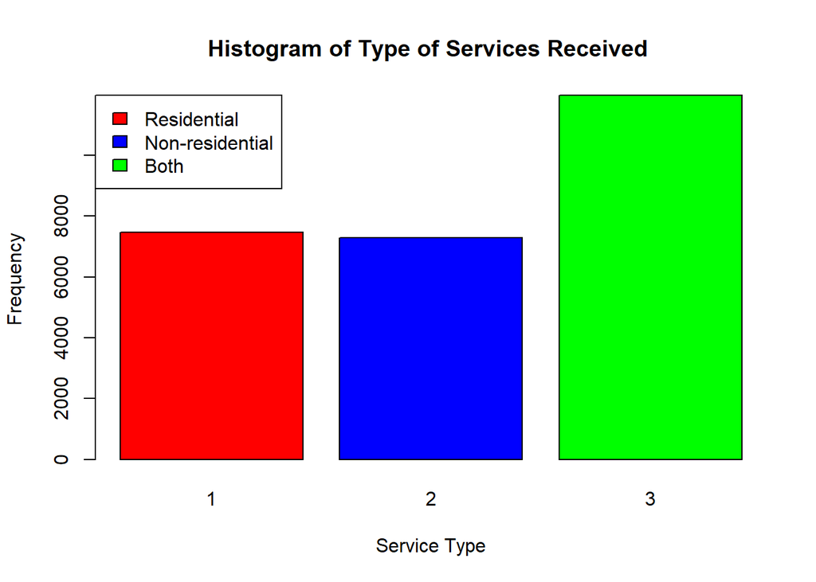

```r
barplot(data, xlab = "Service Type", ylab = "Frequency", col = c("red","blue","green"), main = paste("Histogram of", "Type of Services Received "), legend.text = c("Residential","Non-residential","Both"), args.legend = list(x = "topleft"))
```

Boxplot

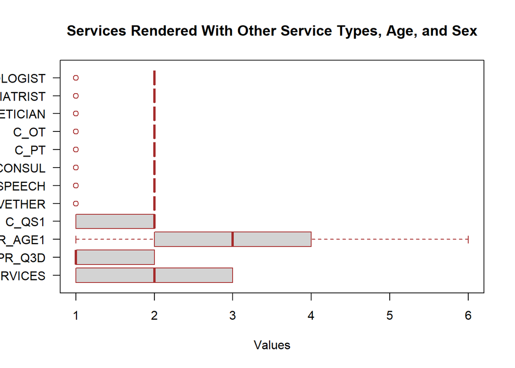

```r
# Creating a Boxplot for services and all other service related data

dss <- dssData3[ ,c("SERVICES","PR_Q3D","PR_AGE1","C_QS1","C_BEHAVETHER","C_AUDIOSPEECH","C_COMMCONSUL","C_PT","C_OT","C_DIETICIAN","C_PSYCHIATRIST","C_PSYCHOLOGIST")]

boxplot(dss,
        main = "Services Rendered With Other Service Types, Age, and Sex",
        at = c(1,2,3,4,5,6,7,8,9,10,11,12),
        names = c("SERVICES","PR_Q3D","PR_AGE1","C_QS1","C_BEHAVETHER","C_AUDIOSPEECH","C_COMMCONSUL","C_PT","C_OT","C_DIETICIAN","C_PSYCHIATRIST","C_PSYCHOLOGIST"),
        border = "brown", xlab = "Values", horizontal = TRUE, las = 1.5)
```

## Plot of subset of data

Creating a Plot of the subset created to check for any correlation relationships between the variables for services rendered.

Since hese are categorical variables, no relationship is expected.

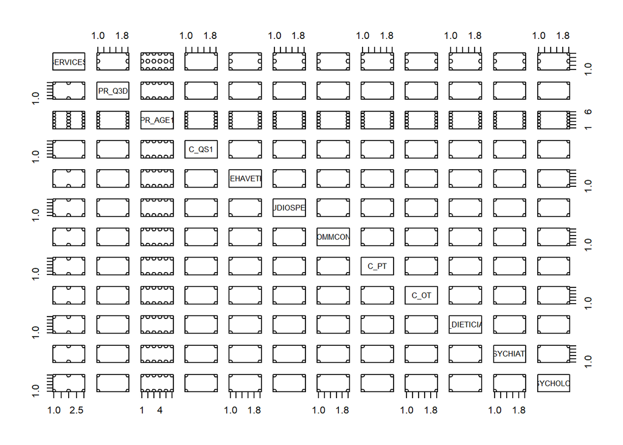

```r
# Plot of Service types as specified in the data dictionary

sub_dssData <- dssData3[ , c("SERVICES","PR_Q3D","PR_AGE1","C_QS1","C_BEHAVETHER","C_AUDIOSPEECH","C_COMMCONSUL","C_PT","C_OT","C_DIETICIAN","C_PSYCHIATRIST","C_PSYCHOLOGIST")]


plot(sub_dssData)
```

```r
# No visible relationship appears to exist between any of the variables.
```